# Summary Instructions for RMarkdown lesson

Gail Clement

Thursday, August 08, 2019

# Introduction: What’s Wrong with the Scientific Paper and What Is the Solution?

View the example of a frustrating Data Availability Statement in Hu, Marwick, et al, Yue Hu, Late Middle Pleistocene Levallois stone-tool technology in southwest China, Nature 565, p 82–85, 2019

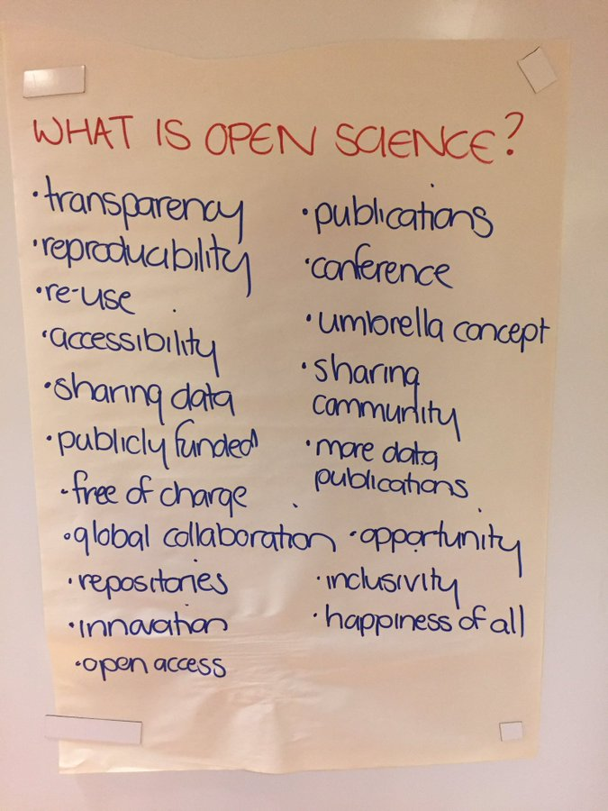

**Open Science Principles from DataTrieste19**

## Consider the Open Science principles we discussed on Monday as you reflect on two questions:

- When you think about reading up on the latest findings in your area, what causes you frustration with the current mode of scholarly communication?
- What features would you like to see in research publishing?

## Vision of the Executable, Reproducible Paper of the future

- [Everpub: A submission for the Open Science Prize](https://github.com/everpub/openscienceprize/blob/master/README.md)
  - Proposed by researchers Tim Head and Titus Brown, developers of Binder
- [“Literate Programming” example by Eglen, Weeks, et al, GigaScience, December 2014](https://academic.oup.com/gigascience/article/3/1/2047-217X-3-3/2682913)
  - View in split mode
  - Refer to section “Availability of supporting data” to see links to supplementary `R` code, data, etc.
- [E-life’s first reproducible article](https://repro.elifesciences.org/example.html#)
  - Note the dynamic version served in Binder (built on the fly)
  - Note that for each plot there appears a reference to an `Rscript` that generated the figure

## What are the Components of Open Authorship?

- Text based authoring with text-based mark up
- Integration of text, code, plots, data in one coherent compendium, or in a persistently linked set of curated resources dispersed across multiple sites (eg publisher site, GitHub Repository, Protocols.io)
- Use of open source tools and platforms
  - Plain text
  - Latex
  - HTML
  - Markdown
  - Pandoc

#### What are the Benefits for Authors of Writing in plain text?

#### What are the Benefits for Readers/Re-users of Writing in plain text?

# How to Get Started with Open Authoring? Return to the command line!

See Etherpad for 1. Instructions to install pandoc on your desktop PC 1. instructions on creating your own GitHub repository for this lesson, and cloning the student files to your desktop computer.

Once `pandoc` and the student files are installed locally, follow these steps:

View the text file with the content we are going to markup for our reproducible research report. Then use `pandoc` to convert it from `.txt` to `.md` format; and from .md to .html format

```
$ ls
$ more DMP0.txt
$ pandoc DMP0.txt -s -o DMP0.md
$ more DMP0.md
$ pandoc DMP0.md -s -o DMP0.html
$ more DMP0.html
```

Open web browser to view the rendered version of the report. (Once inside the browser, press control-O (Oh) to view the files on your local directory). How does the web page look?

Let’s convert the document one more time to `.docx` in case your advisor wants a clean copy of the report printed out.

```
$ pandoc DMP0.html -s -o DMP0.docx
$ more DMP0.docx
```

How does this file look on your computer? Can you read it? Why or why not?

Open Office on your computer and view the file from that application. Look okay now?

Before leaving the command line for RStudio, let’s back up our files to GitHub.

```
$ git add *
$ git commit -m "Uploading pandoc outputs to GitHub"$ git push
```

Now view your GitHub repository to see the newly created files appear there

# Gaining more power and options in RStudio

1. Launch RStudio
2. Select File -> a New project
3. Select Existing directory
4. Navigate to the folder with your lesson files
5. Create the Project
6. Open file `DMPO.md’ in your R Markdown panel
7. Do you see an option for `knitr1` at the top of the panel?
8. Save the file as `DMPO.Rmd` – now do you see the option for `knitr` at the top of the panel?
9. Edit the top portion of the document between the three dashes – this is the YAML [^ Yet Another Markup Language] header that provides instructions to pandoc and to knitr

```
---
author: "Your Name"
title: "My Data Management Plan"
date: "8 August, 2019"
output: html_document
---
```

In the body of the document, markup the headings to distinguish between sections of the DMP

Insert `#` before the main heading Insert `##` before each section heading

Save the file as `DMP1.Rmd` but do not close

Press the `knit` button to render the document as a web page. Did any of the YAML information appear? How do the headings look?

Now `knit` to Word. How does the document look in Office?

Now one last knit, but this time to a slide deck you can show via a Web browser

Revise the YAML output statement as follows:

```
output: slidy_presentation
```

Save the change with control-S and then look at the options on the `knit` menu – select the option for slidy and see what happens!

Can you tell what element(s) in the `DMP1.Rmd` file were used to tell pandoc to insert slide breaks?

Save these changes as `DMP2.Rmd` and take a stretch break – you earned it!

# Markdown that controls appearance

## Lists

- Bulleted List (Navigate to Section 1 of the report and insert a dash and space `-` before each sentence. Save the changes and `knit` to html.
- Bulleted List with Nesting. Use the *4 space rule* to further indent the last three sentences in the list. Save and `knit` to Word
- Numbered List (Navigate to Section 5 and turn each sentence into a numbered list item by inserting a 1, period, and space `1.`before each sentence)
- Numbered List with Nesting (Can you figure out how to further indent the last 2 list items with alphabetical letters?). Save the changes and `knit` to HTML and Word.

## Font styles

Navigate to Section 3 and make the following changes to font style:

- Put the phrase ‘New Mexico Interstate Stream Commission’ into *italics* using the underscore character `_`. This is just for emphasis and is not necessary in many cases. But can you think of any important reasons when certain text strings must be put in *italics* to convey special meaning?
- Emphasize the word ‘public’ by putting it in **boldface** with two underscore characters. This is also not necessary most of the time; it just demonstrates how to markup text when you prefer to add **strong emphasis**.
- Subscripts are produced by surrounding the character to drop lower in the tilde character `~`. Try adding the formula for water next to the word ‘water’ in Section 3.

Navigate to Section 2 for the following markup

- Text that represents `computer code` or other `technical terms` can be produced by surrounding the word or phrase with backticks. This symbol is found above the tilde on your keyboard. It is not the same character as the apostrophe! Represent the phrases ‘Microsoft Access Database’; ESRI ArcGIS; and ‘.txt’ as `computer code`
- Add hyperlinks for websites using the syntax. Make sure there is no extra space between the bracket and the parenthesis.

```
[Name of link](insert url)
```

Save your changes and `knit` to see the results.

## Inline Image

Navigate to the main heading at the top of the report and add a Background section with a Level2 header. Below the new heading type in a sentence: “The field area of this investigation is illustrated below.” Then make room to insert an inline figure representing a map of the study area. The image file to insert is inside the `img` folder in your directory.

```
![Figure 1](img/rio-grande-basin.png)
```

Save the file as `DMP3.Rmd` and `knit` the file to see how the image appears in both HTML and Word.

# Adding Academic Features

**Footnotes**

In Section 2, mark up the last sentence of the section as a footnote using the following markup:

```
^[The FGDC standard was chosen...all the way to end of sentence]
```

Save the changes and `knit`. Where does the footnote appear?

**Citations**

Adding citations is a powerful feature of Markdown and Pandoc but requires a few steps to perform.

1. Make sure you have a well formed `references.bib` file in the file directory. It must contain all the necessary citations represented in `.bibtex` format.
2. Navigate to a sentence that needs a citation at the end.
   1. In the ‘Background’ section, add a citation for the map by inserting the markup `[Source: @Bartolino_1979]`
   2. In Section 4, Paragraph 2, insert a citation after the sentence ending with ’NSF Policies `[See, for example, @Briney_2015]`
3. At the bottom of the document, insert a new section ‘References’ with a level one header. Do not add any content to this section. Pandoc will insert, inside this References section, the full references for each of the citations embedded in the document
4. In the YAML, add the following line at the end of the section (above the closing three dashes.)

```
output: html_document
bibliography: references.bib
---
```

Save the changes, `knit`, and close the file DMP3.Rmd

# Formatting the Document as a Whole

## Table of Contents

In the Files panel of RStudio, copy DMP3.Rmd as DMP4.Rmd using the ‘More’ pull down menu. Open DMP4.Rmd to continue working.

To generate a Table of Contents for the HTML and Word outputs, we need to add a new line to the YAML output sections:

```
output:
  html_document:
    toc: TRUE
    toc_depth: 2
 word_document:
   toc: TRUE
   toc_depth: 2
.
.
---
```

Knit to HTML and Word to view the results.

In the HTML output, Table of Contents can also be floated to the left of the rendered document, by adding an additional line to the output section of the YAML:

```
output:
  html_document:
    toc: TRUE
    toc_depth: 2
    toc_float: TRUE
 word_document:
   toc: TRUE
   toc_depth: 2
.
.
---
```

Knit to HTML to see view the results.

## Section Numbering

*Note: From this point on, we will only be knitting to HTML. The features added from hereon in do not work in Word without adding a specific Word style sheet (more advanced level!), or the features just break the pandoc to Word conversion!*

The sections of your DMP can be automatically numbered by adding yet another line to the output section of the YAML:

```
output:
  html_document:
    toc: TRUE
    toc_depth: 2
    toc_float: TRUE
    number_sections: TRUE
.
.
---
```

Before `knit`ting, remove the manually added section numbers in your DMP.

Also, avoid auto-numbering relevant sections (Main Heading, Background, References) by inserting `{-}` to the end of the heading.

Now go ahead and `knit` to HTML.

## Set a style for the HTML output

The html_document engine uses the [Bootswatch theme library](https://bootswatch.com/) to support different styles of the document. This is a quick and easy way to polish the appearance of your document. (You may also apply Cascading Stylesheets to your HTML output but this, too, is an advanced feature!)

The following themes work well in RMarkdown: cerulean, journal, flaky, darkly, readable, spacelab, united, cosmo, lumen, paper, sandstone, simplex, or yeti

You may also apply a Highlight style to the HTML document. For the purposes of this exercise, let’s use lumen, tango or github.

Here is an example of a YAML output section with the theme and highlight applied:

```
output:
  html_document:
    toc: yes
    toc_depth: 2
    toc_float: yes
    number_sections: yes
    theme: journal
    highlight: github
.
.
---
```

Save and close DMP4.Rmd; from teh Files panel, copy it to DMP5.Rmd

# Adding Code

One of the most powerful and innovative benefits of open authoring in RStudio is the abilility to combine code with the text to provide a more transparent and reuseable report.

## Add code to YAML to keep title page up-to-date

Open DMP5.Rmd for this next set of exercises.

Replace the manually entered date in your YAML header with the either of the following code segments, surrfounded by double quotes and back tick characters on either end of the r code segment.

```
r format(Sys.time(), '%d %B, %Y')

r format(Sys.Date(), '%A, %B %d, %Y')
```

## Add a code chunk in the body of the document

Navigate to the Background section to add a data table under the map. You may add an empty code chunk by finding the green Insert menu at the top of the Rmarkdown panel and selecting `R`

```r
usgs <- read.csv("data/usgs.csv")
head(usgs, 3)
```

```
##      Month ATRISCO_1_SP24.79 ATRISCO_2_SP22.79 ATRISCO_3_SP22.79
## 1 1/1/2001          13780000           5260000          17550000
## 2 2/1/2001          37120000          14480000          19430000
## 3 3/1/2001          46190000          17430000          21310000
##   ATRISCO_4_SP22.79 BURTON_1_SP30.79 BURTON_2_SP14.79 BURTON_3_SP14.79
## 1          17540000         23620000         20750000         10290000
## 2           3710000                0         29370000         16760000
## 3           5890000         29070000          6660000         15900000
##   BURTON_4_SP30.79 BURTON_5_SP37.79 CHARLES_1_SP16.79 CHARLES_2_SP16.79
## 1         20630000         47250000                 0                 0
## 2         29040000         44950000                 0                 0
## 3         28430000         67420000            890000                 0
##   CHARLES_3_SP16.79 CHARLES_4_SP16.79 CHARLES_5_SP33.79 COLLEGE_1_SP23.79
## 1          52130000          46420000          36870000             60000
## 2          44990000          52160000          40830000             30000
```

[output cut: 97 more lines]

`Knit` with `echo=TRUE` and again with `echo=FALSE`. Which do you prefer for your report?

Now add a code chunk with a plot of Old Faithful and change the `echo=` value before `knit`ting.

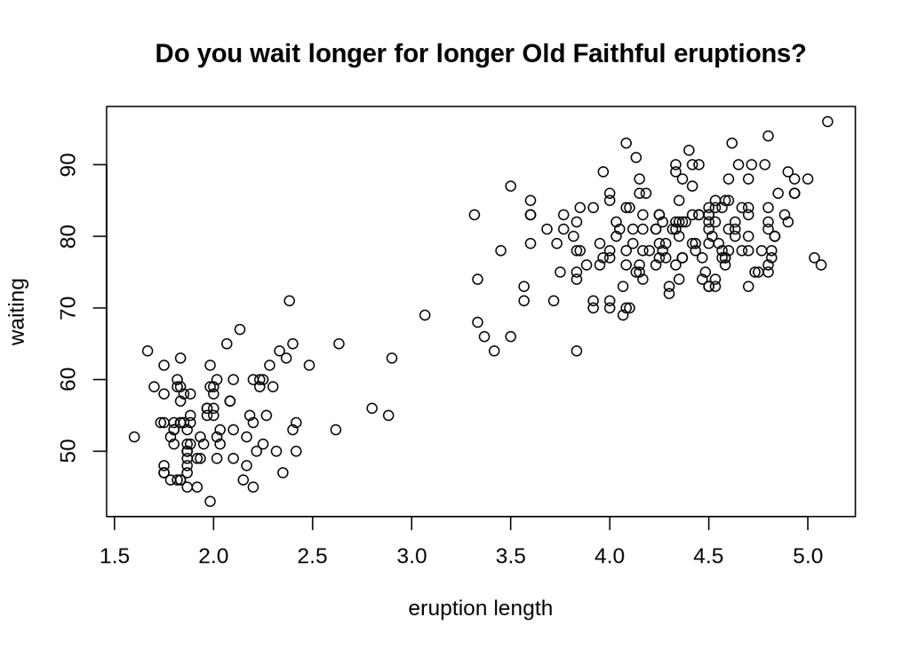

What does the `echo` do?

## Add a code segment inline with the text of the document

Navigate to the Background section, below the data table added a few minutes ago, and insert a line that says “There are x sampling sites in the USGS dataset”

Replace the x with a code segment: 202. What changes, and how could you use dynamic code to ensure your text is always up to date and accurate?

## Save the changes to this file as DMP6.Rmd

# Publishing your report

## Open access distribution

When you save your work in a tangible medium (such as a computer file), copyright automatically attaches to your report. For open access distribution, you need to add an open license to your work that gives readers and re-users permission to do other things with your document. That is because copyright protection on the document otherwise restricts the following actions:

1. Copying the document
2. Modifying the document
3. Publicly distributing the document
4. Publicly performing the document (if you think your report would make a good movie, for example!)
5. Publicly displaying the document (if you think your report would make a beautiful poster, for example!)

By applying an open license, you are not reserving the above-listed rights that copyright restricts by default. Instead of claiming “All rights reserved, you are stating”Some rights reserved." The type of license you attach to your work indicates what rights you are choosing to reserve.

## Selecting an open license with Creative Commons

Creative Commons provides a set of legally-binding, human- and machine- readable licenses to attach to your open access work. To create a license for your report, point your web browser to https://creativecommons.org/choose/ and answer the questions on the form.

Scroll down to the ’Have a web page?` section of the page to see the license text and icon that fits your preferences.

In the box under ‘Copy this code to let your visitors know!’, copy the text for pasting into your report.

Return to DMP6.Rmd and paste in the code above the ‘References’ section. Add a new section for the license by adding a header ‘Disribution License’ above the license code.

`Knit` the document to see how the license appears on your HTML output.

Save the file as ‘index.Rmd’. Then knit the document to HTML in order to generate the web page you will upload to GitHub.

## Publish the report on GitHub

Back at the command line, navigate to the directory with your lesson files and tyoe ‘ls’ to make sure `index.html` is there.

Perform a `git add`, `git commit`, and `git push` on this file so it is on GitHub.

Return to your GitHub repository. Under settings, scroll down to the section for ‘GitHub Pages’ and look for the url for your web site. Copy that url and close the Settings menu.

On the GitHub page for your repository, click on the ‘edit’ button. Add a description for your web page (eg “Reproducible Research Report”) and paste in the url you copied from GitHub pages. Save and close the editing menu.

Click on the url to see the published view of your report! Congratulations, you have published an open-authored and reproducible document!!!